# portfolio_assignment_1.1

Youri Lam

2023-01-04

````
Assignment 1.1


```r
dataset_elegans <- read_excel(here("raw_data/CE.LIQ.FLOW.062_Tidydata.xlsx"))
typeof(dataset_elegans$RawData)
````

```
## [1] "double"
```

```r
typeof(dataset_elegans$compName)
```

```
## [1] "character"
```

```r
typeof(dataset_elegans$compConcentration)
```

```
## [1] "character"
```

Before the data can be visualized, it has to be cleaned up. The dataframe is already in tidy format, but the data types of the columns need to be changed. The variables RawData (the outcome - number of offspring counted as an integer value, after incubation time), compName (the generic name of the compound/chemical) and the compConcentration (the concentration of the compound) are all very important in this research. Expected data types would be double/integer for RawData, character for compName and double for compConcentration. The actual data types of the columns are double for RawData, character for compName and character for compConcentration, as seen above. When plotted, this will result in the following issue:

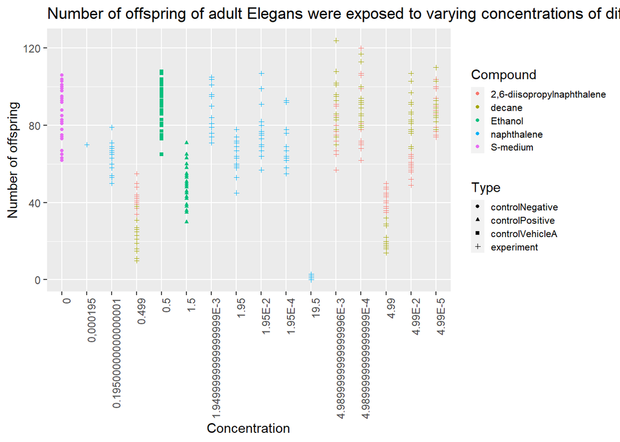

Number of C. elegans offspring under a number of circumstances where the x-axis is ordered alphabetically

```r
plot_wrong <- ggplot(data = dataset_elegans, aes(x = compConcentration, y = RawData))+
  geom_point(aes(color = compName,
                 shape = expType),
             size = 1)+
  rotate_axis_labels("x", 90)+
  labs(x = "Concentration",
       y = "Number of offspring",
       title = "Number of offspring of adult Elegans were exposed to varying concentrations of different compounds, alphabetical",
       shape = "Type",
       color = "Compound")+
       theme(legend.key.size = unit(0.75,"line"),
        legend.text = element_text(size = 8))
plot_wrong
```

As seen in the figure above, the x-axis labels are ordered alphabetically. This is because the data type of the compConcentration is character instead of double.

Looking at the compUnit part of the data, I noticed that not all of the data shares the same compUnit. Some of them are compounds measured in nM and some compounds are measured in percentage. To show this, I made sure to divide the data into two graphs, one for each unit. By changing the date types to the correct ones (including the types talked about previously) and adding jitter, we can make the graph look like this:

```r
dataset_elegans$RawData <- as.integer(dataset_elegans$RawData)
dataset_elegans$compName <- as.factor(dataset_elegans$compName)
dataset_elegans$compConcentration <- as.double(dataset_elegans$compConcentration)
class(dataset_elegans$RawData)
```

```
## [1] "integer"
```

```r
class(dataset_elegans$compName)
```

```
## [1] "factor"
```

```r
class(dataset_elegans$compConcentration)
```

```
## [1] "numeric"
```

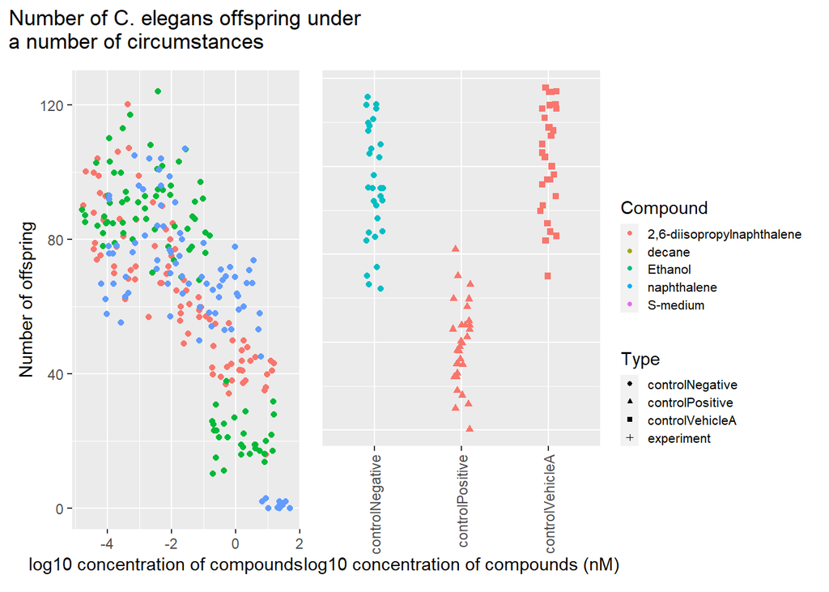

Number of C. elegans offspring under a number of circumstances

```r
#Scatter plot filtered on nM as unit
elegans_nM <- dataset_elegans %>% filter(compUnit == "nM")
scatter_nM <- ggplot(data = elegans_nM, aes(x = log10(compConcentration), y = RawData))+
  geom_jitter(aes(color = compName,
                  shape = expType),
              width = 0.5, height = 0.2)+
  labs(x = "log10 concentration of compounds (nM)",
       y = "Number of offspring")+
  theme(legend.position = "none")


#Scatter plot filtered on pct as unit
elegans_pct <- dataset_elegans %>% filter(compUnit == "pct")
scatter_pct <- ggplot(data = elegans_pct, aes(x = expType, y = RawData))+
  geom_jitter(aes(color = compName,
                  shape = expType),
              width = 0.1, height = 0.2)+
  labs(x = "log10 concentration of compounds (nM)",
       y = "Number of offspring")+
  theme(legend.position = "none",
    axis.text.x=element_text(vjust=0.5, hjust=0.5, size = 8.75),
        axis.text.y = element_blank(),
        axis.ticks.y = element_blank(),
        axis.title.y = element_blank())+
  rotate_axis_labels("x", 90)

legend <- get_legend(plot_wrong)

plot_grid(plot_grid(scatter_nM, scatter_pct),
                 plot_grid(NULL, legend, ncol = 3),
                 rel_widths = c(1, 0.35))+
  plot_annotation("Number of C. elegans offspring under\na number of circumstances")
```

The positive control for this experiment is ethanol. The negative control for this experiment is S-medium.

To make it easier to read the grap, the data needs to be normalized. To do this we adjust the negative control to a value of 1 and adjust the other values in the same way:

```r
#Obtain the mean of the RawData (negativeControl)
neg_control <- dataset_elegans %>% filter(compName == "S-medium") %>% summarize(mean = mean(RawData, na.rm = TRUE))
#Use the mean to calculate fractions
mutated <- dataset_elegans %>% filter(RawData > 0) %>%
  select(RawData, compName, compConcentration, expType) %>% na.omit() %>%
  mutate(normalized = RawData/neg_control$mean)
```

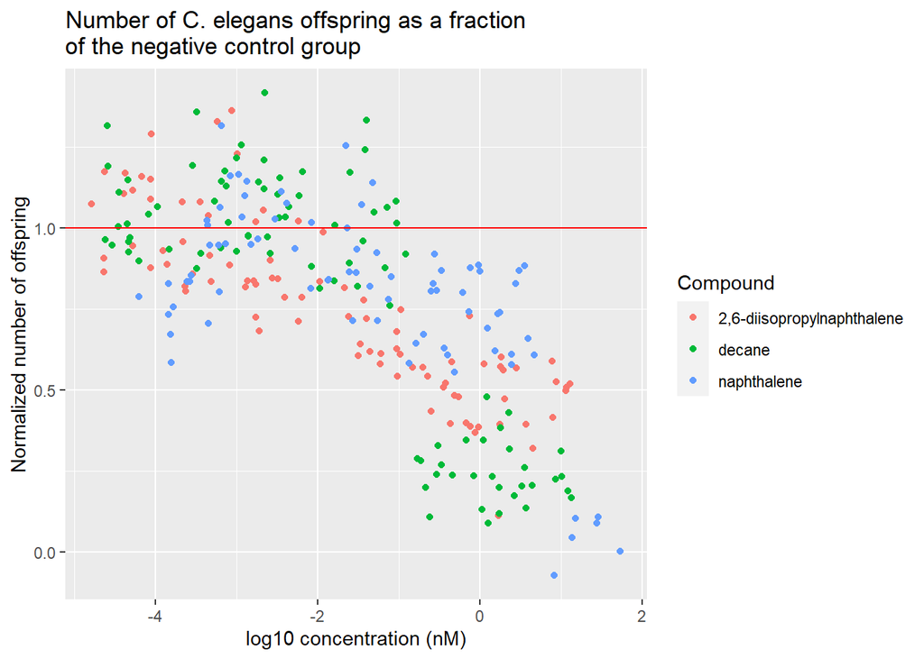

Number of C. elegans offspring as a fraction of the negative control group.

```r
#create normalized plot
normalized_plot <- mutated %>% filter(compName == "2,6-diisopropylnaphthalene" | compName == "decane" | compName == "naphthalene") %>% ggplot(aes(x = log10(compConcentration), y = normalized))+
  geom_jitter(aes(color = compName), width = 0.5, height = 0.1)+
  labs(x = "log10 concentration (nM)",
       y = "Normalized number of offspring",
       title = "Number of C. elegans offspring as a fraction\nof the negative control group",
       color = "Compound")+
  geom_hline(yintercept = 1, color = "red")

normalized_plot
```

Everything below the red line means less offspring than control C. elegans and everything above it has more offspring. For further analysation of the effect i would start by testing normality by performing a Shapiro-Wilk test. If unusual, i would normalize the data like done above. If normal, i would start an ANOVA between de different conditions. I would end with the post-hoc tests, to check in what combination of groups the difference is.